# Electric_Vehicle_Registration

## Electric Vehicles

This notebook is about the electric cars that are currently registered through Washington State Department of Licensing (DOL). This DataSet contais almost 200.000 rows of raw Data

In this analysis of the data we can know which are the model cars has more regsiters in the in the DOL and which are the cities that count the most of electric cars user and also wich are the cars brand are the most relevant in the market.

The DataSet includes:

**Content**:

```
1. Data Exploration
2. Data Visualization
```

**Features**:

```
1. VIN
2. Country
3. City
4. State
5. Postal Code
6. Model Year
7. Make
8. Model
9. Electric Vechicle Type
10. Vehicle (CAVF) Eligibility
11. Electric Range
12. Base SMRP
13. Legislative Distric
14. DOL Vehicle ID
15. Vehicle Location
16. Electric Utility
17. 2020 Censun track
```

## Questions to be Answered

1. Which are the most comercial model ?
2. Which are the cities with most electric vehicles ?
3. Which are the brands with the most electric vehicles ?

```python
import pandas as pd
import matplotlib.pyplot as plt
import seaborn as sns
```

## Data Exploration

```python
df = pd.read_csv('Electric_Vehicle_Population_Data.csv')
df
```

|  | VIN (1-10) | County | City | State | Postal Code | Model Year | Make | Model | Electric Vehicle Type | Clean Alternative Fuel Vehicle (CAFV) Eligibility | Electric Range | Base MSRP | Legislative District | DOL Vehicle ID | Vehicle Location | Electric Utility | 2020 Census Tract |
| --- | --- | --- | --- | --- | --- | --- | --- | --- | --- | --- | --- | --- | --- | --- | --- | --- | --- |
| 0 | WAUTPBFF4H | King | Seattle | WA | 98126.0 | 2017 | AUDI | A3 | Plug-in Hybrid Electric Vehicle (PHEV) | Not eligible due to low battery range | 16 | 0 | 34.0 | 235085336 | POINT (-122.374105 47.54468) | CITY OF SEATTLE - (WA)\|CITY OF TACOMA - (WA) | 5.303301e+10 |
| 1 | WAUUPBFF2J | Thurston | Olympia | WA | 98502.0 | 2018 | AUDI | A3 | Plug-in Hybrid Electric Vehicle (PHEV) | Not eligible due to low battery range | 16 | 0 | 22.0 | 237896795 | POINT (-122.943445 47.059252) | PUGET SOUND ENERGY INC | 5.306701e+10 |
| 2 | 5YJSA1E22H | Thurston | Lacey | WA | 98516.0 | 2017 | TESLA | MODEL S | Battery Electric Vehicle (BEV) | Clean Alternative Fuel Vehicle Eligible | 210 | 0 | 22.0 | 154498865 | POINT (-122.78083 47.083975) | PUGET SOUND ENERGY INC | 5.306701e+10 |
| 3 | 1C4JJXP62M | Thurston | Tenino | WA | 98589.0 | 2021 | JEEP | WRANGLER | Plug-in Hybrid Electric Vehicle (PHEV) | Not eligible due to low battery range | 25 | 0 | 20.0 | 154525493 | POINT (-122.85403 46.856085) | PUGET SOUND ENERGY INC | 5.306701e+10 |
| 4 | 5YJ3E1EC9L | Yakima | Yakima | WA | 98902.0 | 2020 | TESLA | MODEL 3 | Battery Electric Vehicle (BEV) | Clean Alternative Fuel Vehicle Eligible | 308 | 0 | 14.0 | 225996361 | POINT (-120.524012 46.5973939) | PACIFICORP | 5.307700e+10 |
| ... | ... | ... | ... | ... | ... | ... | ... | ... | ... | ... | ... | ... | ... | ... | ... | ... | ... |
| 181453 | 50EA1TEA7P | Douglas | East Wenatchee | WA | 98802.0 | 2023 | LUCID | AIR | Battery Electric Vehicle (BEV) | Eligibility unknown as battery range has not b... | 0 | 0 | 12.0 | 244207316 | POINT (-120.28674 47.4176) | PUD NO 1 OF DOUGLAS COUNTY | 5.301795e+10 |
| 181454 | 1C4JJXP60N | Spokane | Spokane Valley | WA | 99206.0 | 2022 | JEEP | WRANGLER | Plug-in Hybrid Electric Vehicle (PHEV) | Not eligible due to low battery range | 21 | 0 | 4.0 | 207180774 | POINT (-117.24549 47.6534) | BONNEVILLE POWER ADMINISTRATION\|\|AVISTA CORP\|\|... | 5.306301e+10 |
| 181455 | 5YJ3E1EA0M | King | Enumclaw | WA | 98022.0 | 2021 | TESLA | MODEL 3 | Battery Electric Vehicle (BEV) | Eligibility unknown as battery range has not b... | 0 | 0 | 31.0 | 161934202 | POINT (-121.98953 47.20347) | PUGET SOUND ENERGY INC\|\|CITY OF TACOMA - (WA) | 5.303303e+10 |
| 181456 | 5YJ3E1EC8L | Clark | Vancouver | WA | 98682.0 | 2020 | TESLA | MODEL 3 | Battery Electric Vehicle (BEV) | Clean Alternative Fuel Vehicle Eligible | 308 | 0 | 18.0 | 100859650 | POINT (-122.5286031 45.6686601) | BONNEVILLE POWER ADMINISTRATION\|\|PUD NO 1 OF C... | 5.301104e+10 |
| 181457 | 5YJSA1E27F | Whatcom | Bellingham | WA | 98225.0 | 2015 | TESLA | MODEL S | Battery Electric Vehicle (BEV) | Clean Alternative Fuel Vehicle Eligible | 208 | 0 | 42.0 | 256731576 | POINT (-122.486115 48.761615) | PUGET SOUND ENERGY INC\|\|PUD NO 1 OF WHATCOM CO... | 5.307300e+10 |

181458 rows × 17 columns

```python
df.shape
```

```
(181458, 17)
```

```python
df.describe()
```

|  | Postal Code | Model Year | Electric Range | Base MSRP | Legislative District | DOL Vehicle ID | 2020 Census Tract |
| --- | --- | --- | --- | --- | --- | --- | --- |
| count | 181455.000000 | 181458.000000 | 181458.000000 | 181458.000000 | 181060.000000 | 1.814580e+05 | 1.814550e+05 |
| mean | 98174.050718 | 2020.581793 | 57.826665 | 1040.236749 | 29.106904 | 2.214128e+08 | 5.297575e+10 |
| std | 2414.241968 | 2.991140 | 91.396074 | 8228.989085 | 14.892342 | 7.528561e+07 | 1.594876e+09 |
| min | 1545.000000 | 1997.000000 | 0.000000 | 0.000000 | 1.000000 | 4.385000e+03 | 1.001020e+09 |
| 25% | 98052.000000 | 2019.000000 | 0.000000 | 0.000000 | 18.000000 | 1.830687e+08 | 5.303301e+10 |
| 50% | 98122.000000 | 2022.000000 | 0.000000 | 0.000000 | 33.000000 | 2.289155e+08 | 5.303303e+10 |
| 75% | 98370.000000 | 2023.000000 | 75.000000 | 0.000000 | 42.000000 | 2.561320e+08 | 5.305307e+10 |
| max | 99577.000000 | 2024.000000 | 337.000000 | 845000.000000 | 49.000000 | 4.792548e+08 | 5.603300e+10 |

```python
df.info()
```

```
<class 'pandas.core.frame.DataFrame'>
RangeIndex: 181458 entries, 0 to 181457
Data columns (total 17 columns):
 #   Column                                             Non-Null Count   Dtype
---  ------                                             --------------   -----
 0   VIN (1-10)                                         181458 non-null  object
 1   County                                             181455 non-null  object
 2   City                                               181455 non-null  object
 3   State                                              181458 non-null  object
 4   Postal Code                                        181455 non-null  float64
 5   Model Year                                         181458 non-null  int64
 6   Make                                               181458 non-null  object
 7   Model                                              181458 non-null  object
 8   Electric Vehicle Type                              181458 non-null  object
 9   Clean Alternative Fuel Vehicle (CAFV) Eligibility  181458 non-null  object
 10  Electric Range                                     181458 non-null  int64
 11  Base MSRP                                          181458 non-null  int64
 12  Legislative District                               181060 non-null  float64
 13  DOL Vehicle ID                                     181458 non-null  int64
 14  Vehicle Location                                   181450 non-null  object
 15  Electric Utility                                   181455 non-null  object
 16  2020 Census Tract                                  181455 non-null  float64
dtypes: float64(3), int64(4), object(10)
memory usage: 23.5+ MB
```

```python
df.isnull().sum()
```

```
VIN (1-10)                                             0
County                                                 3
City                                                   3
State                                                  0
Postal Code                                            3
Model Year                                             0
Make                                                   0
Model                                                  0
Electric Vehicle Type                                  0
Clean Alternative Fuel Vehicle (CAFV) Eligibility      0
Electric Range                                         0
Base MSRP                                              0
Legislative District                                 398
DOL Vehicle ID                                         0
Vehicle Location                                       8
Electric Utility                                       3
2020 Census Tract                                      3
dtype: int64
```

```python
df.dropna(inplace = True)
```

```python
df.isnull().sum()
```

```
VIN (1-10)                                           0
County                                               0
City                                                 0
State                                                0
Postal Code                                          0
Model Year                                           0
Make                                                 0
Model                                                0
Electric Vehicle Type                                0
Clean Alternative Fuel Vehicle (CAFV) Eligibility    0
Electric Range                                       0
Base MSRP                                            0
Legislative District                                 0
DOL Vehicle ID                                       0
Vehicle Location                                     0
Electric Utility                                     0
2020 Census Tract                                    0
dtype: int64
```

```python
df.shape
```

```
(181055, 17)
```

```python
df.duplicated().sum()
```

```
0
```

## Which are the most comercial model ?

```python
most_registered_model = df['Model'].value_counts().nlargest(10).reset_index()
most_registered_model
```

|  | Model | count |
| --- | --- | --- |
| 0 | MODEL Y | 36937 |
| 1 | MODEL 3 | 30065 |
| 2 | LEAF | 13343 |
| 3 | MODEL S | 7706 |
| 4 | BOLT EV | 6925 |
| 5 | MODEL X | 5871 |
| 6 | VOLT | 4785 |
| 7 | ID.4 | 4083 |
| 8 | WRANGLER | 3533 |
| 9 | MUSTANG MACH-E | 3481 |

```
(array([0, 1, 2, 3, 4, 5, 6, 7, 8, 9]),
 [Text(0, 0, 'MODEL Y'),
```

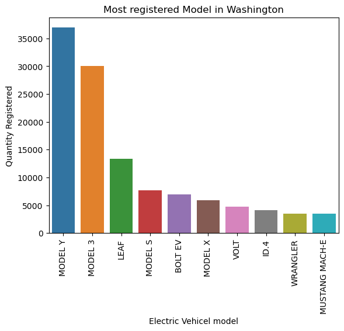

```python
most_registered_model_colums = ['Model', 'count']
sns.barplot(x='Model', y='count', data = most_registered_model)
plt.title('Most registered Model in Washington')
plt.xlabel('Electric Vehicel model')
plt.ylabel('Quantity Registered')
plt.xticks(rotation=90)
```

## Report

In this graph, we can see the different models of electric cars registered in the state of Washington. It is evident that the models predominantly represented in the graph belong to Tesla. It can be said that Tesla is the company that has made the most advancements in the field of electric cars, also implementing autonomous vehicles.

The other models are from various brands such as Nissan, Chevrolet, Ford, etc. While they may not have as much impact as Tesla, they still hold a certain percentage in the graph. These models are likely more affordable, but perhaps not the first choice for individuals looking to purchase from these brands.

A significant factor in why Tesla also dominates this percentage is that all Tesla vehicles are electric. Therefore, when collecting this type of information, it is inevitable for Tesla to appear in these situations.s

## Which are the cities with most electric vehicles ?

```python
cities_most_electric_vehicle = df['City'].value_counts().nlargest(10).reset_index()
cities_most_electric_vehicle
```

|  | City | count |
| --- | --- | --- |
| 0 | Seattle | 30045 |
| 1 | Bellevue | 9116 |
| 2 | Redmond | 6568 |
| 3 | Vancouver | 6329 |
| 4 | Bothell | 5961 |
| 5 | Kirkland | 5465 |
| 6 | Sammamish | 5350 |
| 7 | Renton | 5104 |
| 8 | Olympia | 4397 |
| 9 | Tacoma | 3792 |

```
(array([0, 1, 2, 3, 4, 5, 6, 7, 8, 9]),
 [Text(0, 0, 'Seattle'),
```

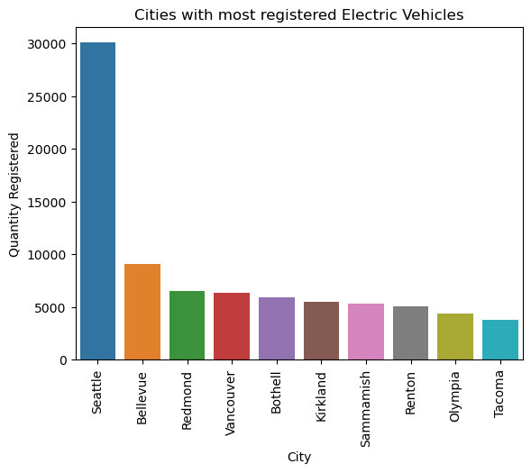

```python
most_registered_model_colums = ['Model', 'count']
sns.barplot(x='City', y='count', data = cities_most_electric_vehicle)
plt.title('Cities with most registered Electric Vehicles')
plt.xlabel('City')
plt.ylabel('Quantity Registered')
plt.xticks(rotation=90)
```

## Report

As we can see in the following graph, we can observe how electric vehicles are distributed in the state of Washington in different cities. Clearly, Seattle stands out with a significantly notable percentage of electric vehicles compared to the others. This graph allows us to compare the number of registered vehicles in each city. The graph indicates that, unlike other cities, Seattle is taking the lead in implementing electric vehicles for daily use, as gasoline vehicles contribute significantly to environmental pollution, while electric vehicles help mitigate this environmental impact. Another factor that likely contributes to this significant difference with Seattle is probably the purchasing power of other cities. As mentioned earlier, Tesla models are the most dominant, being more modern than their competitors, but this does not change the fact that Tesla cars are quite expensive and not everyone has the financial capacity to acquire this type of vehicle. To conclude, it can be said that electric cars are a relatively new technology. In this graph, the percentage of people who still prefer gasoline vehicles is not ruled out, as these vehicles can be more durable and reliable. Although the graph shows that electric cars are more dominant in Seattle, it does not mean that electric vehicles prevail over gasoline vehicles in Seattle. e.

```python
electrics_brands = df['Make'].value_counts().nlargest(5).reset_index()
electrics_brands
```

|  | Make | count |
| --- | --- | --- |
| 0 | TESLA | 80627 |
| 1 | NISSAN | 14024 |
| 2 | CHEVROLET | 13838 |
| 3 | FORD | 9503 |
| 4 | BMW | 7666 |

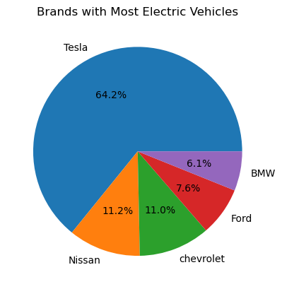

```python
labels = ['Tesla' , 'Nissan', 'chevrolet', 'Ford', 'BMW']
plt.pie(electrics_brands['count'], autopct = '%1.1f%%', labels= labels )
plt.title('Brands with Most Electric Vehicles')
plt.show()
```

## Report

In the following graph, we can observe the distribution of different electric vehicle brands in the state of Washington. As mentioned earlier, it is no coincidence that Tesla dominates as the most predominant electric vehicle brand.

This is due to Tesla's vehicles having autonomous driving capabilities, meaning they can drive themselves. While Tesla vehicles are not cheap, the various features they offer justify their price.

On the other hand, other brands do not hold as significant a percentage, posing no real challenge to Tesla in the market. These brands need to identify what Tesla is doing differently in order to capture a larger share and increase competitiveness.

It is also worth noting that the brands present, aside from Tesla, do not focus on creating electric vehicles; rather, they are focused on other niches and view electric vehicles as a secondary market opportunity.electric vehicle market.